# seminrExtras 1.0.0 — Feature Tour

Nicholas P. Danks

2026-04-20

# Introduction

`seminrExtras` 1.0.0 is now on CRAN. It extends the `seminr` PLS-SEM workflow with eight new assessment methods:

| Method | Function(s) | What it tells you |
| --- | --- | --- |
| COA | `assess_coa()` | Why / for whom your model fails to generalise |
| NCA | `assess_nca()` | Which predictors are **necessary** (not just sufficient) |
| NCA-ESSE | `assess_nca_esse()` | How robust NCA conclusions are to extreme responses |
| cIPMA | `assess_cipma()` / `assess_ipma()` | Managerial priority map, optionally with necessity |
| FIMIX-PLS | `assess_fimix()` / `assess_fimix_compare()` | EM-based latent-class segmentation |
| PLS-POS | `assess_pos()` / `assess_pos_compare()` / `pos_segments()` | Prediction-oriented segmentation (max ΣR²) |
| CTA-PLS | `assess_cta()` | Is this measurement model actually reflective? |
| PCM | `assess_pcm()` | Does the mediator improve out-of-sample prediction? |

Plus hardened `assess_cvpat()`, `assess_cvpat_compare()`, and `congruence_test()`.

```r
# install.packages("seminrExtras")
library(seminr)
library(seminrExtras)
packageVersion("seminrExtras")
```

```
## [1] '1.0.0'
```

Two bundled datasets are used throughout:

- `mobi` — MOBI customer satisfaction (from `seminr`)
- `corp_rep_data` — Corporate reputation (from `seminr`)

# 1. Base models

## 1a. MOBI model (reflective, for NCA / cIPMA / CTA / PCM / congruence)

```r
mobi_mm <- constructs(
  composite("Image",        multi_items("IMAG", 1:5)),
  composite("Expectation",  multi_items("CUEX", 1:3)),
  composite("Value",        multi_items("PERV", 1:2)),
  composite("Satisfaction", multi_items("CUSA", 1:3)),
  composite("Loyalty",      multi_items("CUSL", 1:3))
)

mobi_sm <- relationships(
  paths(from = "Image",        to = c("Expectation", "Satisfaction", "Loyalty")),
  paths(from = "Expectation",  to = c("Value", "Satisfaction")),
  paths(from = "Value",        to = "Satisfaction"),
  paths(from = "Satisfaction", to = "Loyalty")
)

mobi_pls <- estimate_pls(
  data              = mobi,
  measurement_model = mobi_mm,
  structural_model  = mobi_sm
)
```

```r
corp_rep_mm <- constructs(
  composite("QUAL", multi_items("qual_", 1:8), weights = mode_B),
  composite("PERF", multi_items("perf_", 1:5), weights = mode_B),
  composite("CSOR", multi_items("csor_", 1:5), weights = mode_B),
  composite("ATTR", multi_items("attr_", 1:3), weights = mode_B),
  composite("COMP", multi_items("comp_", 1:3)),
  composite("LIKE", multi_items("like_", 1:3)),
  composite("CUSA", single_item("cusa")),
  composite("CUSL", multi_items("cusl_", 1:3))
)

corp_rep_sm <- relationships(
  paths(from = c("QUAL", "PERF", "CSOR", "ATTR"), to = c("COMP", "LIKE")),
  paths(from = c("COMP", "LIKE"),                 to = c("CUSA", "CUSL")),
  paths(from = "CUSA",                            to = "CUSL")
)

corp_pls <- estimate_pls(
  data              = corp_rep_data,
  measurement_model = corp_rep_mm,
  structural_model  = corp_rep_sm,
  missing           = mean_replacement,
  missing_value     = "-99"
)
```

## 1c. Simple COA model (reduced corporate reputation)

```r
corp_mm_simple <- constructs(
  composite("COMP", multi_items("comp_", 1:3)),
  composite("LIKE", multi_items("like_", 1:3)),
  composite("CUSA", single_item("cusa")),
  composite("CUSL", multi_items("cusl_", 1:3))
)

corp_sm_simple <- relationships(
  paths(from = c("COMP", "LIKE"), to = "CUSA"),
  paths(from = "CUSA",            to = "CUSL")
)

corp_model <- estimate_pls(
  data              = corp_rep_data,
  measurement_model = corp_mm_simple,
  structural_model  = corp_sm_simple,
  missing           = mean_replacement,
  missing_value     = "-99"
)
```

# 2. Composite Overfit Analysis (COA)

Diagnoses *why* and *for whom* the model fails to generalise. Returns predictive deviance, a decision tree that groups deviant cases, and unstable-path analysis.

```r
coa_result <- assess_coa(
  corp_model,
  focal_construct = "CUSL",
  noFolds = 10, reps = 1, cores = 1,
  seed = 123
)

print(coa_result)
```

```
## Composite Overfit Analysis (COA)
## ================================
## Focal construct: CUSL
## Deviance bounds: 0.025 - 0.975
## Observations: 344
##
## Prediction Metrics:
##   In-sample MSE:  0.522
##   Out-of-sample MSE: 0.5231
##   Overfit ratio:     0.0022
##
## Deviant Cases:
##   Groups: 4 ( A = 3, B = 3, C = 2, D = 6 )
##   Unique deviants: 4
```

```r
summary(coa_result)
```

```
## Composite Overfit Analysis (COA) Summary
## =========================================
## Focal construct: CUSL
## Observations: 344
## Deviance bounds: 0.025 - 0.975
##
## Prediction Metrics:
##         Metric       Value
##         IS_MSE 0.521990663
##        OOS_MSE 0.523138987
##  Overfit_Ratio 0.002199894
##
## Deviant Groups:
##  Group Size Root_Node
##      A    3       268
##      B    3        39
##      C    2         5
##      D    6         3
##
## Unique deviants: 4
##
## Parameter Instability (max |path_coef diff|):
##  Group Max_Path_Diff
##      A   0.009893759
##      B   0.018626833
##      C   0.005045965
##      D   0.022216510
```

### Plots

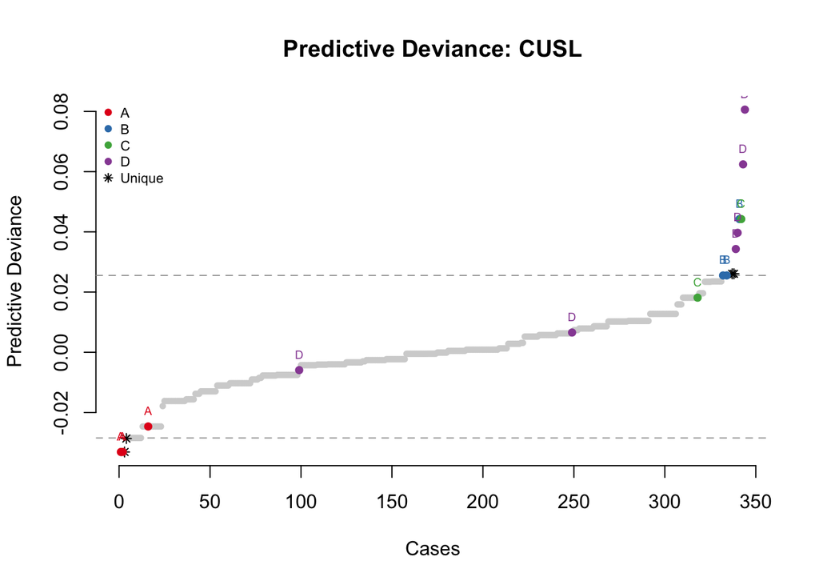

```r
plot(coa_result, type = "pd")      # predictive deviance distribution
```

[figure not shown]

```r
plot(coa_result, type = "tree")    # decision tree
```

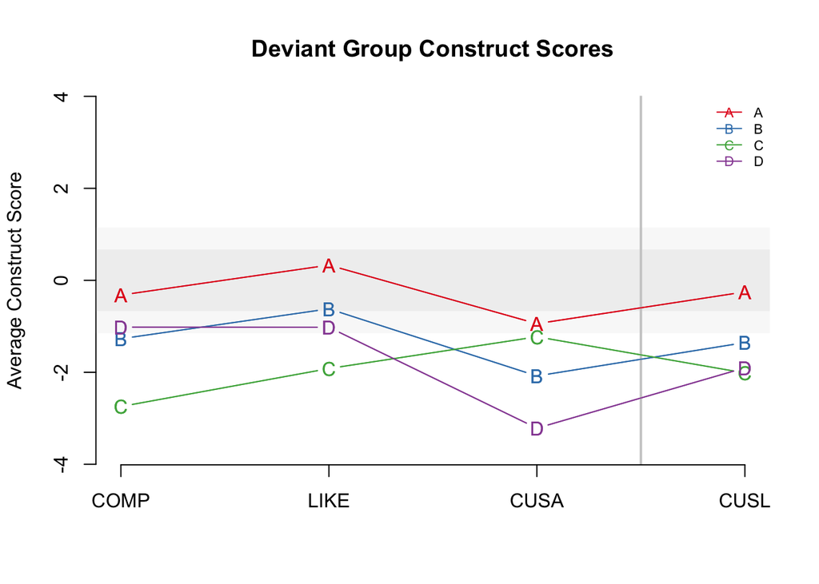

```r
plot(coa_result, type = "groups")  # deviant group highlights
```

### Step-by-step COA

```r
pd     <- predictive_deviance(corp_model,
                              focal_construct = "CUSL",
                              noFolds = 10, reps = 1, cores = 1,
                              seed = 123)
tree   <- deviance_tree(pd, deviance_bounds = c(0.025, 0.975))
instab <- unstable_params(corp_model, tree$deviant_groups, params = "path_coef")
print(instab)
```

```
## $A
## $A$cases
## [1]  12 162 259
##
## $A$param_diffs
## $A$param_diffs$path_coef
##      COMP LIKE         CUSA        CUSL
## COMP    0    0 -0.007714185 0.000000000
## LIKE    0    0  0.009893759 0.000000000
## CUSA    0    0  0.000000000 0.001327771
## CUSL    0    0  0.000000000 0.000000000
##
##
##
## $B
## $B$cases
## [1]  35 114 186
##
## $B$param_diffs
## $B$param_diffs$path_coef
##      COMP LIKE        CUSA         CUSL
## COMP    0    0 -0.01862683  0.000000000
## LIKE    0    0  0.01158709  0.000000000
## CUSA    0    0  0.00000000 -0.005318762
## CUSL    0    0  0.00000000  0.000000000
##
##
##
## $C
## $C$cases
## [1] 297 311
##
## $C$param_diffs
## $C$param_diffs$path_coef
##      COMP LIKE          CUSA         CUSL
## COMP    0    0  0.0005863733  0.000000000
## LIKE    0    0 -0.0050459655  0.000000000
## CUSA    0    0  0.0000000000 -0.004058067
## CUSL    0    0  0.0000000000  0.000000000
##
##
##
## $D
## $D$cases
## [1]  29  61  63 106 149 197
##
## $D$param_diffs
## $D$param_diffs$path_coef
##      COMP LIKE        CUSA       CUSL
## COMP    0    0 -0.02221651  0.0000000
## LIKE    0    0  0.01277128  0.0000000
## CUSA    0    0  0.00000000 -0.0212177
## CUSL    0    0  0.00000000  0.0000000
##
##
##
## attr(,"class")
## [1] "coa_unstable" "list"
```

```r
# Inspect the rules and competing splits for one deviant group
first_group <- names(tree$deviant_groups)[1]
group_rules(first_group, coa_result)             # decision rule for group "A"
```

```
##   construct        gte         lt
## 1      CUSA -2.5050509  0.9029112
## 2      COMP -2.6219498         NA
## 3      LIKE  0.2285191  0.3594257
## 4      CUSL         NA -0.2007597
```

```r
competes(tree$group_roots[[first_group]], tree)  # competing splits at that node
```

```
##   criterion sign      value   improve
## 1      LIKE   <   0.3594257 0.6630509
## 2      CUSA   <  -0.8010698 0.2569164
## 3      COMP   <  -0.9193789 0.2504132
## 4      CUSL   >= -1.5408427 0.1688486
```

# 3. Necessary Condition Analysis (NCA)

Tests **necessity**, not sufficiency. No external `NCA` package required — CE-FDH and CR-FDH ceiling lines are built in.

```r
nca_sat <- assess_nca(
  mobi_pls,
  target   = "Satisfaction",
  test.rep = 1000,
  seed     = 123
)

print(nca_sat)
```

```
## Necessary Condition Analysis (NCA)
## ==================================
## Target: Satisfaction
## Predictors: Image, Expectation, Value
## Ceilings: ce_fdh, cr_fdh
## Observations: 250
##
## Effect Sizes (d):
##             ce_fdh cr_fdh
## Image        0.292  0.261
## Expectation  0.193  0.199
## Value        0.000  0.000
##
## NCA Effect Sizes (d >= 0.1 indicates a necessary condition)
##
## Permutation p-values:
##             ce_fdh cr_fdh
## Image        0.000  0.000
## Expectation  0.000  0.000
## Value        1.000  1.000
##
## NCA Significance (permutation test p-values)
##
## Necessary conditions (d >= 0.1, p < 0.05): Image, Expectation
```

```r
summary(nca_sat)
```

```
## Necessary Condition Analysis (NCA) Summary
## ============================================
## Target: Satisfaction
## Predictors: Image, Expectation, Value
## Ceilings: ce_fdh, cr_fdh
## Observations: 250
##
## Effect Sizes (d):
##             ce_fdh cr_fdh
## Image        0.292  0.261
## Expectation  0.193  0.199
## Value        0.000  0.000
##
## NCA Effect Sizes (d >= 0.1 indicates a necessary condition)
##
## Permutation p-values:
##             ce_fdh cr_fdh
## Image        0.000  0.000
## Expectation  0.000  0.000
## Value        1.000  1.000
##
## NCA Significance (permutation test p-values)
##
## Necessary conditions (d >= 0.1, p < 0.05): Image, Expectation
##
## Bottleneck table (ce_fdh):
##    Satisfaction Image Expectation Value
## 1             0   0.0         0.0     0
## 2            10  11.5        10.7     0
## 3            20  11.5        11.3     0
## 4            30  11.5        13.7     0
## 5            40  11.5        13.7     0
## 6            50  17.2        16.4     0
## 7            60  23.7        19.0     0
## 8            70  44.8        19.3     0
## 9            80  46.9        19.3     0
## 10           90  71.6        42.0     0
## 11          100  74.0        62.3     0
##
## Bottleneck table (cr_fdh):
##    Satisfaction Image Expectation Value
## 1             0    NA          NA     0
## 2            10    NA          NA     0
## 3            20    NA          NA     0
## 4            30   0.5         5.0     0
## 5            40  11.0        11.6     0
## 6            50  21.5        18.2     0
## 7            60  32.1        24.8     0
## 8            70  42.6        31.4     0
## 9            80  53.1        38.0     0
## 10           90  63.6        44.6     0
## 11          100  74.1        51.2     0
```

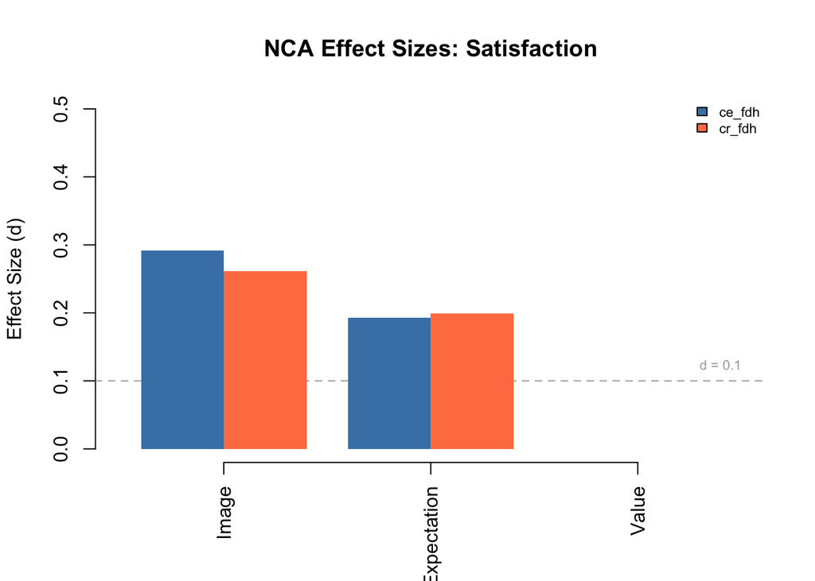

```r
plot(nca_sat, type = "effects")   # effect size bar plot
```

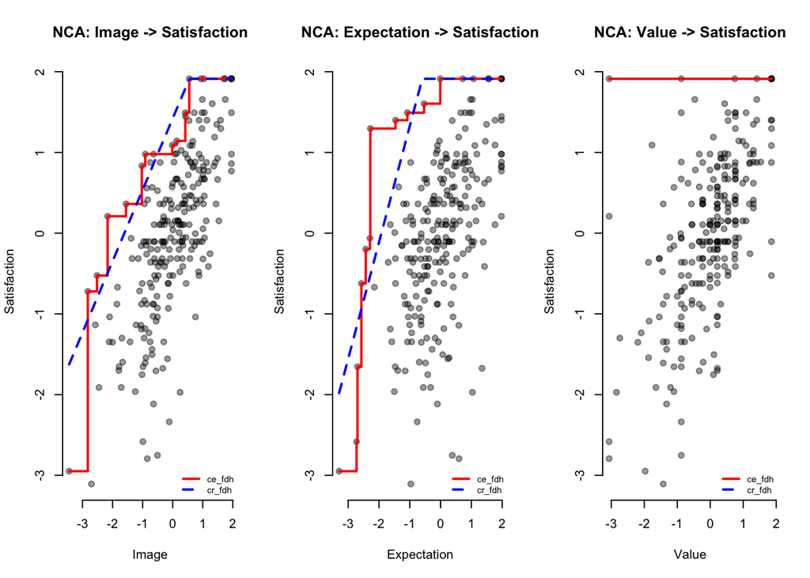

```r
plot(nca_sat, type = "scatter")   # ceiling-line scatter plots
```

# 4. NCA-ESSE (Effect Size Sensitivity Extension)

Varies the ECDF threshold, removes upper-left observations, and compares the empirical effect size drop against a uniform benchmark (Becker et al., 2026).

```r
esse_sat <- assess_nca_esse(
  mobi_pls,
  target     = "Satisfaction",
  thresholds = seq(0, 0.05, by = 0.005),
  seed       = 123
)

print(esse_sat)
```

```
## NCA-ESSE: Effect Size Sensitivity Extension
## =============================================
## Target: Satisfaction
## Predictors: Image, Expectation, Value
## Ceiling: ce_fdh
## Observations: 250
## Thresholds: 0% to 5%
##
## Empirical effect sizes by ECDF threshold:
##       Image Expectation  Value
## 0%   0.2917      0.1930 0.0000
## 0.5% 0.2787      0.1821 0.1191
## 1%   0.3118      0.1923 0.2620
## 1.5% 0.3227      0.2095 0.3661
## 2%   0.3366      0.2228 0.2666
## 2.5% 0.3375      0.2361 0.2840
## 3%   0.3280      0.2410 0.3364
## 3.5% 0.3454      0.2510 0.3414
## 4%   0.2796      0.2117 0.1975
## 4.5% 0.3161      0.2072 0.2065
## 5%   0.3224      0.2097 0.2157
##
## Benchmark (uniform) effect sizes:
##     0%   0.5%     1%   1.5%     2%   2.5%     3%   3.5%     4%   4.5%     5%
## 0.0000 0.0315 0.0561 0.0780 0.0982 0.1172 0.1352 0.1523 0.1688 0.1845 0.1998
##
## Sensitivity (empirical - benchmark):
##       Image Expectation  Value
## 0%   0.2917      0.1930 0.0000
## 0.5% 0.2472      0.1506 0.0876
## 1%   0.2557      0.1362 0.2060
## 1.5% 0.2447      0.1315 0.2882
## 2%   0.2383      0.1245 0.1684
## 2.5% 0.2202      0.1189 0.1668
## 3%   0.1928      0.1058 0.2013
## 3.5% 0.1931      0.0987 0.1891
## 4%   0.1109      0.0429 0.0288
## 4.5% 0.1315      0.0226 0.0220
## 5%   0.1226      0.0099 0.0159
```

```r
summary(esse_sat)
```

```
## NCA-ESSE Summary (Becker et al., 2026)
## =======================================
## Target: Satisfaction
## Ceiling: ce_fdh
## Observations: 250
##
## Predictor: Image
## ------------------------------------------------------------
##  ECDF_threshold Empirical_d Benchmark_d Difference
##           0.000      0.2917      0.0000     0.2917
##           0.005      0.2787      0.0315     0.2472
##           0.010      0.3118      0.0561     0.2557
##           0.015      0.3227      0.0780     0.2447
##           0.020      0.3366      0.0982     0.2383
##           0.025      0.3375      0.1172     0.2202
##           0.030      0.3280      0.1352     0.1928
##           0.035      0.3454      0.1523     0.1931
##           0.040      0.2796      0.1688     0.1109
##           0.045      0.3161      0.1845     0.1315
##           0.050      0.3224      0.1998     0.1226
##
## Predictor: Expectation
## ------------------------------------------------------------
##  ECDF_threshold Empirical_d Benchmark_d Difference
##           0.000      0.1930      0.0000     0.1930
##           0.005      0.1821      0.0315     0.1506
##           0.010      0.1923      0.0561     0.1362
##           0.015      0.2095      0.0780     0.1315
##           0.020      0.2228      0.0982     0.1245
##           0.025      0.2361      0.1172     0.1189
##           0.030      0.2410      0.1352     0.1058
##           0.035      0.2510      0.1523     0.0987
##           0.040      0.2117      0.1688     0.0429
##           0.045      0.2072      0.1845     0.0226
##           0.050      0.2097      0.1998     0.0099
##
## Predictor: Value
## ------------------------------------------------------------
##  ECDF_threshold Empirical_d Benchmark_d Difference
##           0.000      0.0000      0.0000     0.0000
##           0.005      0.1191      0.0315     0.0876
##           0.010      0.2620      0.0561     0.2060
##           0.015      0.3661      0.0780     0.2882
##           0.020      0.2666      0.0982     0.1684
##           0.025      0.2840      0.1172     0.1668
##           0.030      0.3364      0.1352     0.2013
##           0.035      0.3414      0.1523     0.1891
##           0.040      0.1975      0.1688     0.0288
##           0.045      0.2065      0.1845     0.0220
##           0.050      0.2157      0.1998     0.0159
```

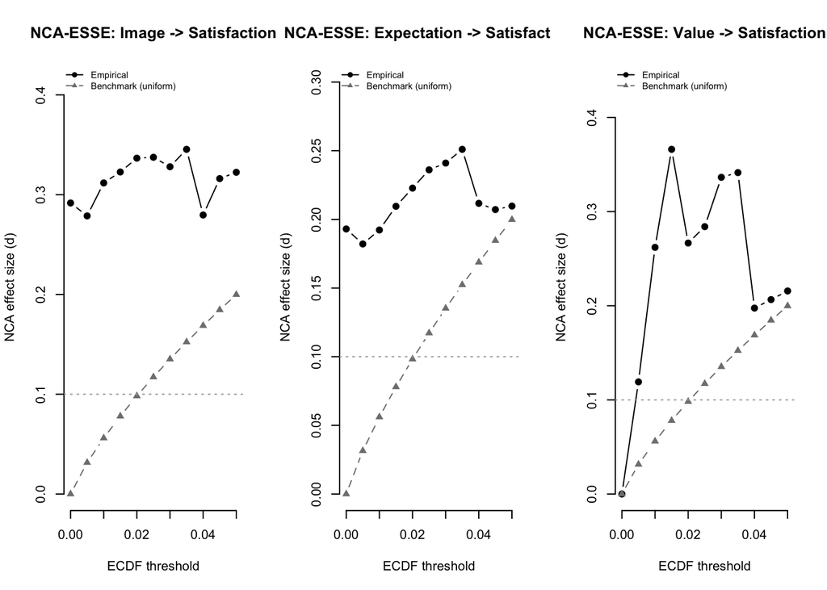

```r
plot(esse_sat, type = "sensitivity")   # Fig. 4, Becker et al. (2026)
```

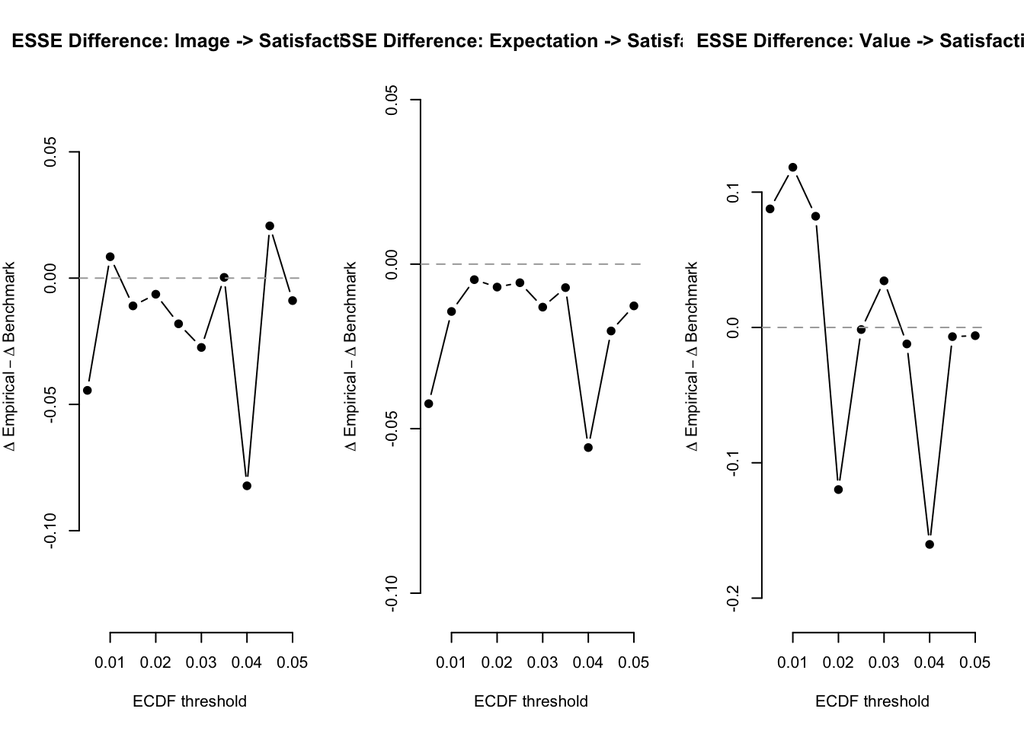

```r
plot(esse_sat, type = "difference")    # Fig. 6, Becker et al. (2026)
```

# 5. cIPMA (Combined Importance–Performance Map Analysis)

`assess_ipma()` is a convenience wrapper for IPMA alone; `assess_cipma()` overlays NCA necessity onto the IPMA map.

## IPMA only

```r
ipma_result <- assess_ipma(
  mobi_pls,
  target    = "Loyalty",
  scale_min = 1,
  scale_max = 10
)

print(ipma_result)
```

```
## Importance-Performance Map Analysis (IPMA)
## ============================================
## Target: Loyalty
## Constructs: Image, Expectation, Value, Satisfaction
## Scale range: 1 - 10
## Observations: 250
##
## Importance-Performance Results:
##     Construct Unstd. Total Effect Std. Total Effect Performance
##         Image              0.8167            0.5105       73.15
##   Expectation              0.2267            0.1455       72.40
##         Value              0.1739            0.1631       61.95
##  Satisfaction              0.7512            0.5110       71.90
##
## IPMA Classification:
##     Construct         Priority
##         Image Important driver
##   Expectation     Low priority
##         Value     Low priority
##  Satisfaction Important driver
```

```r
summary(ipma_result)
```

```
## Importance-Performance Map Analysis (IPMA) Summary
## ====================================================
## Target: Loyalty
## Scale range: 1 - 10
## Observations: 250
##
## Importance (Unstandardized Total Effects on Loyalty ):
##        Image  Expectation        Value Satisfaction
##       0.8167       0.2267       0.1739       0.7512
##
## Importance (Standardized Total Effects on Loyalty ):
##        Image  Expectation        Value Satisfaction
##       0.5105       0.1455       0.1631       0.5110
##
## Performance (0-100 rescaled):
##        Image  Expectation        Value Satisfaction
##        73.15        72.40        61.95        71.90
##
## Construct Classification:
##     Construct Importance Performance High_Importance Necessary         Priority
##         Image     0.8167       73.15            TRUE     FALSE Important driver
##   Expectation     0.2267       72.40           FALSE     FALSE     Low priority
##         Value     0.1739       61.95           FALSE     FALSE     Low priority
##  Satisfaction     0.7512       71.90            TRUE     FALSE Important driver
```

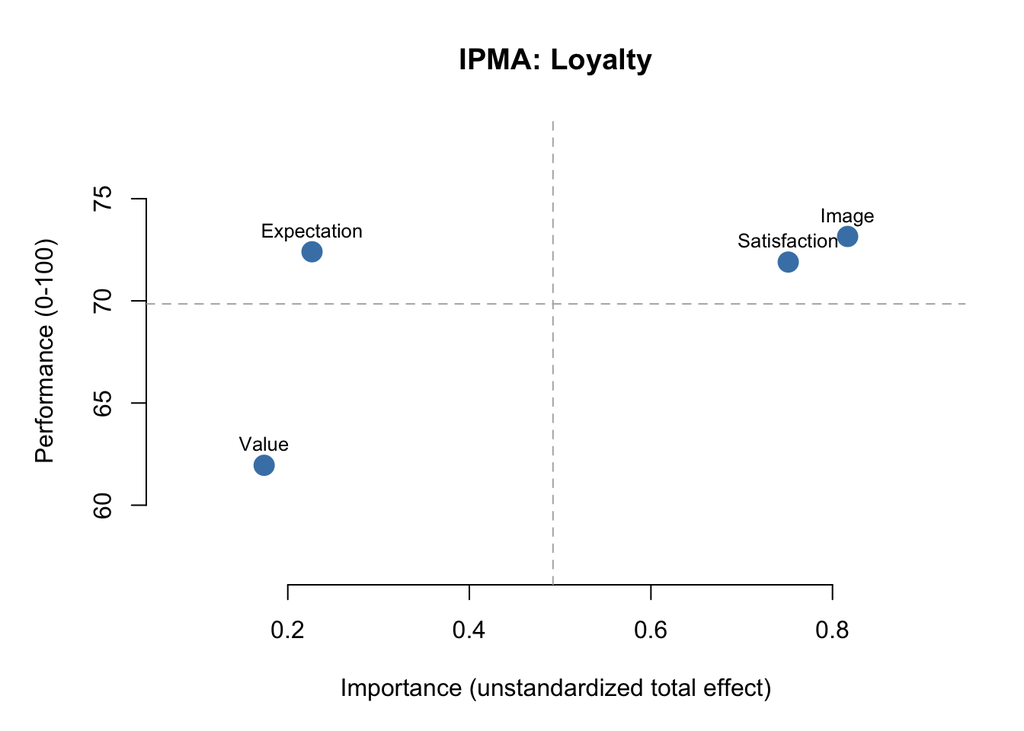

```r
plot(ipma_result, type = "ipma")
```

## cIPMA (IPMA + necessity)

```r
cipma_result <- assess_cipma(
  mobi_pls,
  target       = "Loyalty",
  scale_min    = 1,
  scale_max    = 10,
  nca_test.rep = 1000,
  seed         = 123
)

print(cipma_result)
```

```
## Combined Importance-Performance Map Analysis (cIPMA)
## =====================================================
## Target: Loyalty
## Constructs: Image, Expectation, Value, Satisfaction
## Scale range: 1 - 10
## Observations: 250
##
## Importance-Performance Results:
##     Construct Unstd. Total Effect Std. Total Effect Performance
##         Image              0.8167            0.5105       73.15
##   Expectation              0.2267            0.1455       72.40
##         Value              0.1739            0.1631       61.95
##  Satisfaction              0.7512            0.5110       71.90
##
## Necessary Conditions (NCA):
##     Construct d (ce_fdh) d (cr_fdh) Necessary
##         Image     0.1512     0.1335       Yes
##   Expectation     0.1287     0.1032       Yes
##         Value     0.0150     0.0075        No
##  Satisfaction     0.1430     0.1246       Yes
##
## cIPMA Classification:
##     Construct        Priority
##         Image    Top priority
##   Expectation Bottleneck risk
##         Value    Low priority
##  Satisfaction    Top priority
```

```r
summary(cipma_result)
```

```
## Combined Importance-Performance Map Analysis (cIPMA) Summary
## =============================================================
## Target: Loyalty
## Scale range: 1 - 10
## Observations: 250
##
## Importance (Unstandardized Total Effects on Loyalty ):
##        Image  Expectation        Value Satisfaction
##       0.8167       0.2267       0.1739       0.7512
##
## Importance (Standardized Total Effects on Loyalty ):
##        Image  Expectation        Value Satisfaction
##       0.5105       0.1455       0.1631       0.5110
##
## Performance (0-100 rescaled):
##        Image  Expectation        Value Satisfaction
##        73.15        72.40        61.95        71.90
##
## NCA Effect Sizes:
##              ce_fdh cr_fdh
## Image        0.1512 0.1335
## Expectation  0.1287 0.1032
## Value        0.0150 0.0075
## Satisfaction 0.1430 0.1246
##
## NCA Permutation p-values:
##              ce_fdh cr_fdh
## Image         0.004  0.008
## Expectation   0.015  0.019
## Value         0.593  0.615
## Satisfaction  0.000  0.000
##
## Necessary conditions: Image, Expectation, Satisfaction
##
## Bottleneck table (ce_fdh):
##    Loyalty Image Expectation Value Satisfaction
## 1        0   0.0         0.0   0.0          0.0
## 2       10   0.0         0.0   0.0          3.2
## 3       20  11.5        10.7   0.0          7.1
## 4       30  16.2        10.7   0.0         10.4
```

[output cut: 13 more lines]

```
## 4       30   7.1         0.6    NA          6.9
## 5       40  10.2         4.7    NA          9.7
## 6       50  13.3         8.7    NA         12.4
## 7       60  16.4        12.7    NA         15.2
## 8       70  19.4        16.8    NA         18.0
## 9       80  22.5        20.8    NA         20.7
## 10      90  25.6        24.8    NA         23.5
## 11     100  28.6        28.9  44.4         26.3
##
## Construct Classification:
##     Construct Importance Performance High_Importance Necessary        Priority
##         Image     0.8167       73.15            TRUE      TRUE    Top priority
##   Expectation     0.2267       72.40           FALSE      TRUE Bottleneck risk
##         Value     0.1739       61.95           FALSE     FALSE    Low priority
##  Satisfaction     0.7512       71.90            TRUE      TRUE    Top priority
```

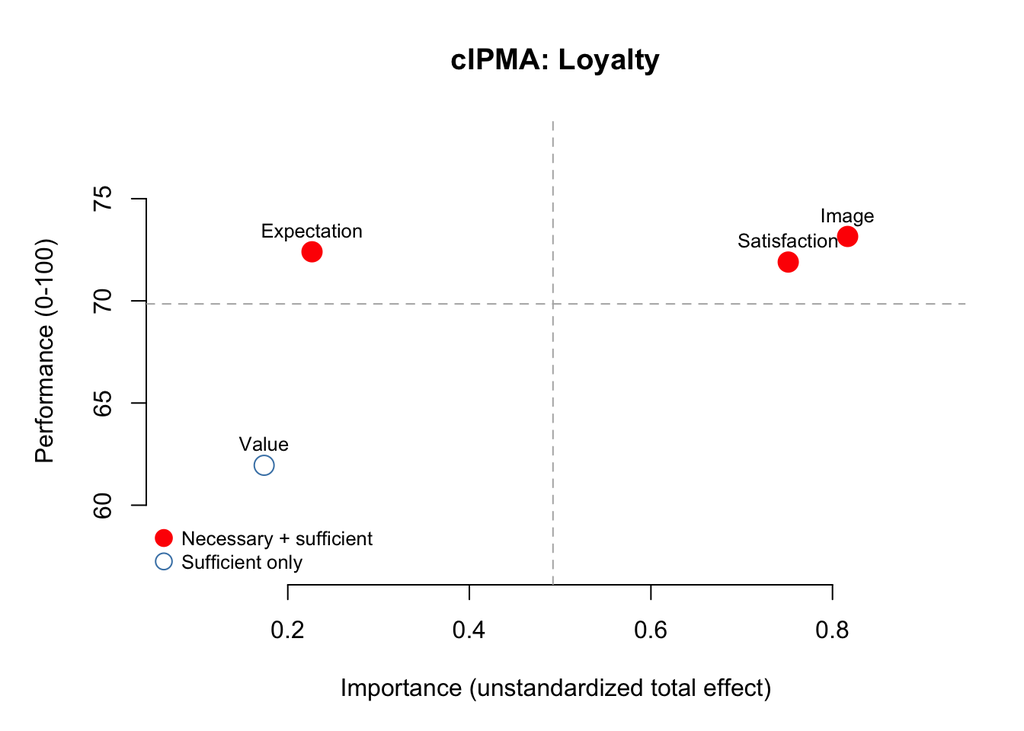

```r
plot(cipma_result, type = "cipma")                       # IPMA + NCA overlay
```

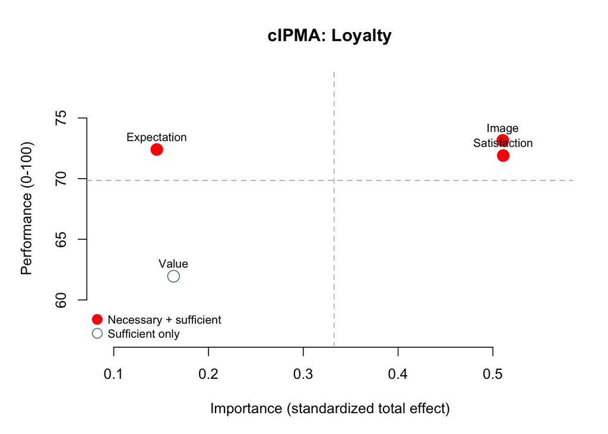

```r
plot(cipma_result, importance_metric = "standardized")   # standardized total effects
```

# 6. FIMIX-PLS (EM-based latent class segmentation)

Uncovers unobserved heterogeneity. Multi-start EM with information-criteria comparison across K.

## Single K

```r
fimix_k2 <- assess_fimix(corp_pls, K = 2, nstart = 10, seed = 123)

print(fimix_k2)
```

```
## FIMIX-PLS Analysis
## ==================
## Segments: 2
## Observations: 344
## Converged: Yes ( 104 iterations )
## Random starts: 10
##
## Segment Proportions:
##    Segment Proportion Size
##  Segment 1     0.4087  118
##  Segment 2     0.5913  226
##
## Fit Criteria:
##       lnL     AIC    AIC3    AIC4     BIC    CAIC     EN
##  -1376.69 2839.39 2882.39 2925.39 3004.54 3047.54 0.4873
##
## Segment Path Coefficients:
##
##   Segment 1 :
##  From   To Coefficient
##  QUAL COMP      0.6345
##  PERF COMP      0.2744
##  CSOR COMP     -0.2286
##  ATTR COMP      0.1038
##  QUAL LIKE      0.5920
##  PERF LIKE     -0.0525
##  CSOR LIKE     -0.0318
##  ATTR LIKE      0.1770
##  COMP CUSA      0.3869
##  LIKE CUSA      0.4486
##  COMP CUSL      0.2501
##  LIKE CUSL      0.3283
##  CUSA CUSL      0.3536
##
##   Segment 2 :
##  From   To Coefficient
##  QUAL COMP      0.2952
##  PERF COMP      0.2067
##  CSOR COMP      0.3251
##  ATTR COMP      0.1746
##  QUAL LIKE      0.1915
##  PERF LIKE      0.2480
##  CSOR LIKE      0.3039
##  ATTR LIKE      0.1881
##  COMP CUSA      0.1864
##  LIKE CUSA      0.2003
##  COMP CUSL     -0.0186
##  LIKE CUSL      0.3270
##  CUSA CUSL      0.3943
```

```r
summary(fimix_k2)
```

```
## FIMIX-PLS Analysis Summary
## ==========================
## Segments: 2
## Observations: 344
## Free parameters: 43
## Converged: Yes ( 104 iterations )
## Random starts: 10
##
## Segment Proportions:
## Segment_1 Segment_2
##    0.4087    0.5913
##
## Fit Criteria:
##        lnL        AIC       AIC3       AIC4        BIC       CAIC         HQ
## -1376.6943  2839.3885  2882.3885  2925.3885  3004.5361  3047.5361  2905.1648
##       MDL5         EN
##  2878.9623     0.4873
##
## --- Segment 1 ---
## Intercepts:
##    COMP    LIKE    CUSA    CUSL
##  0.2189 -0.1076 -0.3943 -0.2994
## Path Coefficients:
##  From   To Coefficient
##  QUAL COMP      0.6345
##  PERF COMP      0.2744
##  CSOR COMP     -0.2286
##  ATTR COMP      0.1038
##  QUAL LIKE      0.5920
##  PERF LIKE     -0.0525
##  CSOR LIKE     -0.0318
##  ATTR LIKE      0.1770
##  COMP CUSA      0.3869
##  LIKE CUSA      0.4486
##  COMP CUSL      0.2501
##  LIKE CUSL      0.3283
##  CUSA CUSL      0.3536
## Residual Variances:
##   COMP   LIKE   CUSA   CUSL
## 0.3259 0.4965 0.7807 0.6977
```

[output cut: 8 more lines]

```
##  PERF COMP      0.2067
##  CSOR COMP      0.3251
##  ATTR COMP      0.1746
##  QUAL LIKE      0.1915
##  PERF LIKE      0.2480
##  CSOR LIKE      0.3039
##  ATTR LIKE      0.1881
##  COMP CUSA      0.1864
##  LIKE CUSA      0.2003
##  COMP CUSL     -0.0186
##  LIKE CUSL      0.3270
##  CUSA CUSL      0.3943
## Residual Variances:
##   COMP   LIKE   CUSA   CUSL
## 0.2659 0.3480 0.4050 0.1680
```

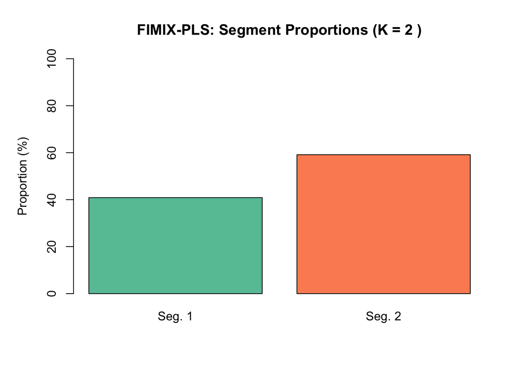

```r
plot(fimix_k2)
```

## Compare across K

```r
fimix_compare <- assess_fimix_compare(
  corp_pls,
  K_range = 2:4,
  nstart  = 10,
  seed    = 123
)

print(fimix_compare)
```

```
## FIMIX-PLS Segment Selection
## ===========================
## K range: 2 to 4
##
## Fit Criteria:
##  K      lnL     AIC    AIC3    AIC4     BIC    CAIC      HQ    MDL5     EN
##  2 -1376.69 2839.39 2882.39 2925.39 3004.54 3047.54 2905.16 2878.96 0.4873
##  3 -1321.68 2773.37 2838.37 2903.37 3023.01 3088.01 2872.80 2833.19 0.6340
##  4 -1290.10 2754.20 2841.20 2928.20 3088.34 3175.34 2887.28 2834.27 0.6629
##
## Best K by criterion:
##    AIC : 4
##    AIC3 : 3
##    AIC4 : 3
##    BIC : 2
##    CAIC : 2
##    EN (best): 4
```

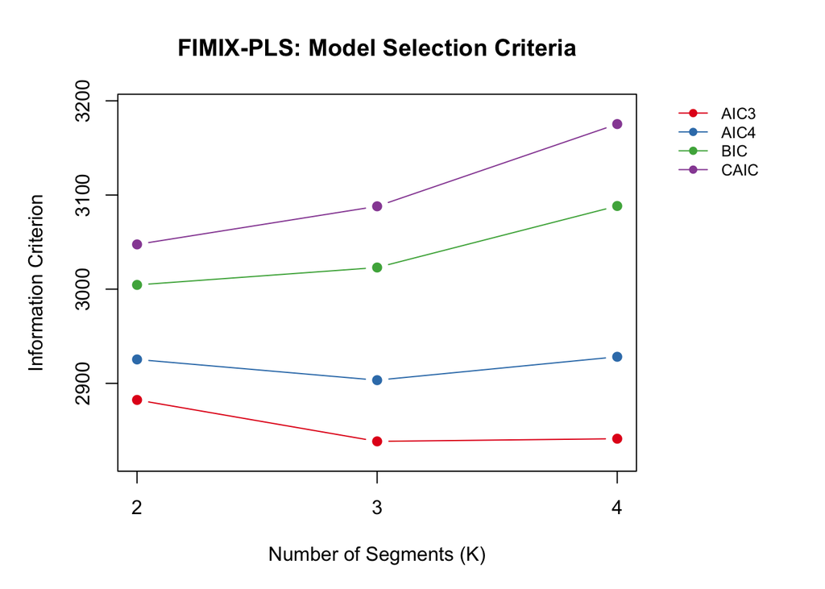

```r
plot(fimix_compare)   # IC across K
```

# 7. PLS-POS (Prediction-Oriented Segmentation)

Maximises Σ R² across segments (Becker et al., 2013). No distributional assumptions, detects heterogeneity in both structural and formative measurement models.

## Single K

```r
pos_k2 <- assess_pos(corp_pls, K = 2, nstart = 10, max_iter = 100, seed = 123)

print(pos_k2)
```

```
## PLS-POS Analysis
## ================
## Segments: 2
## Observations: 344
## Converged: Yes ( 68 iterations )
## Random starts: 10
## Objective (Sum R²): 4.8026
##
## Segment Sizes:
##    Segment Size Proportion
##  Segment 1  159     0.4622
##  Segment 2  185     0.5378
##
## R² per Endogenous Construct:
##      Segment 1 Segment 2 Global
## COMP    0.8043    0.5872 0.6309
## LIKE    0.6159    0.6614 0.5576
## CUSA    0.5348    0.2932 0.2919
## CUSL    0.6974    0.6084 0.5620
##
## Segment Path Coefficients:
##
##   Segment 1 :
##  From   To Coefficient
##  QUAL COMP      0.1765
##  PERF COMP      0.5059
##  CSOR COMP      0.2550
##  ATTR COMP      0.0460
##  QUAL LIKE     -0.0668
##  PERF LIKE      0.1745
##  CSOR LIKE      0.3721
##  ATTR LIKE      0.4025
##  COMP CUSA      0.5583
##  LIKE CUSA      0.2320
##  COMP CUSL      0.1773
##  LIKE CUSL     -0.0389
##  CUSA CUSL      0.7244
##
##   Segment 2 :
##  From   To Coefficient
##  QUAL COMP      0.7510
##  PERF COMP      0.0283
##  CSOR COMP     -0.1526
##  ATTR COMP      0.1267
##  QUAL LIKE      0.7855
##  PERF LIKE     -0.0191
##  CSOR LIKE      0.1165
##  ATTR LIKE     -0.0600
##  COMP CUSA     -0.3203
##  LIKE CUSA      0.6817
##  COMP CUSL     -0.2490
##  LIKE CUSL      0.7578
##  CUSA CUSL      0.2309
```

```r
summary(pos_k2)
```

```
## PLS-POS Analysis — Detailed Summary
## ======================================
## Segments: 2 | Observations: 344
## Objective (Sum R²): 4.8026
## Converged: Yes ( 68 iterations )
## Random starts: 10
## Start objectives: 4.8026, 4.5605, 4.6819, 4.7407, 4.5684, 4.4232, 4.7631, 4.5952, 4.721, 4.7688
##
## Segment Sizes:
##   Segment 1: 159 (46.2%)
##   Segment 2: 185 (53.8%)
##
## R² Comparison (Segment vs Global):
##      Segment 1 Segment 2 Global
## COMP    0.8043    0.5872 0.6309
## LIKE    0.6159    0.6614 0.5576
## CUSA    0.5348    0.2932 0.2919
## CUSL    0.6974    0.6084 0.5620
##
## Path Coefficients per Segment:
##          Path Global   Seg.1   Seg.2
##  QUAL -> COMP 0.4297  0.1765  0.7510
##  PERF -> COMP 0.2955  0.5059  0.0283
##  CSOR -> COMP 0.0589  0.2550 -0.1526
##  ATTR -> COMP 0.0861  0.0460  0.1267
##  QUAL -> LIKE 0.3800 -0.0668  0.7855
##  PERF -> LIKE 0.1170  0.1745 -0.0191
##  CSOR -> LIKE 0.1784  0.3721  0.1165
##  ATTR -> LIKE 0.1671  0.4025 -0.0600
##  COMP -> CUSA 0.1455  0.5583 -0.3203
##  LIKE -> CUSA 0.4357  0.2320  0.6817
##  COMP -> CUSL 0.0057  0.1773 -0.2490
##  LIKE -> CUSL 0.3440 -0.0389  0.7578
##  CUSA -> CUSL 0.5050  0.7244  0.2309
```

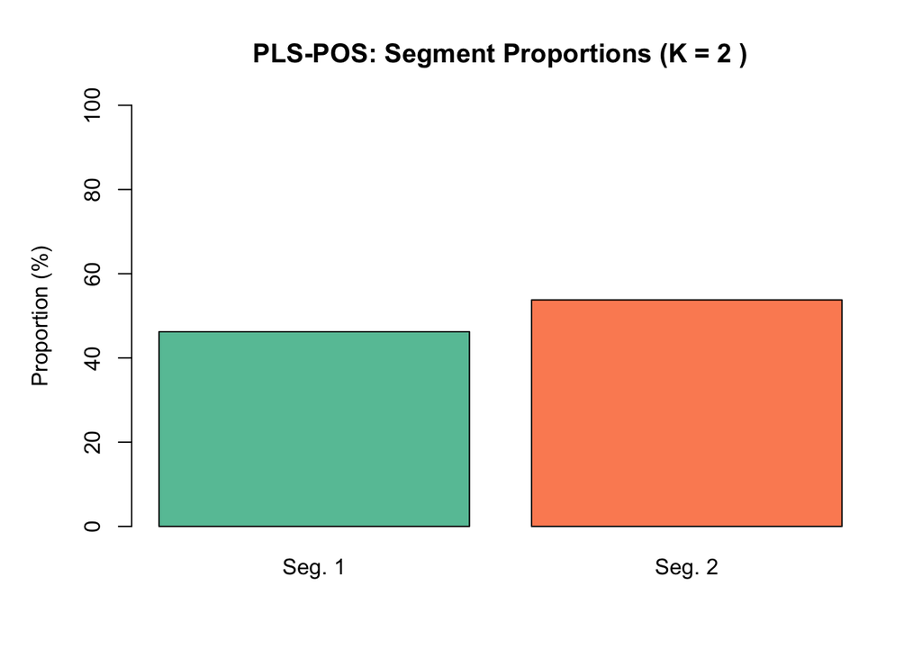

```r
plot(pos_k2, type = "segments")
```

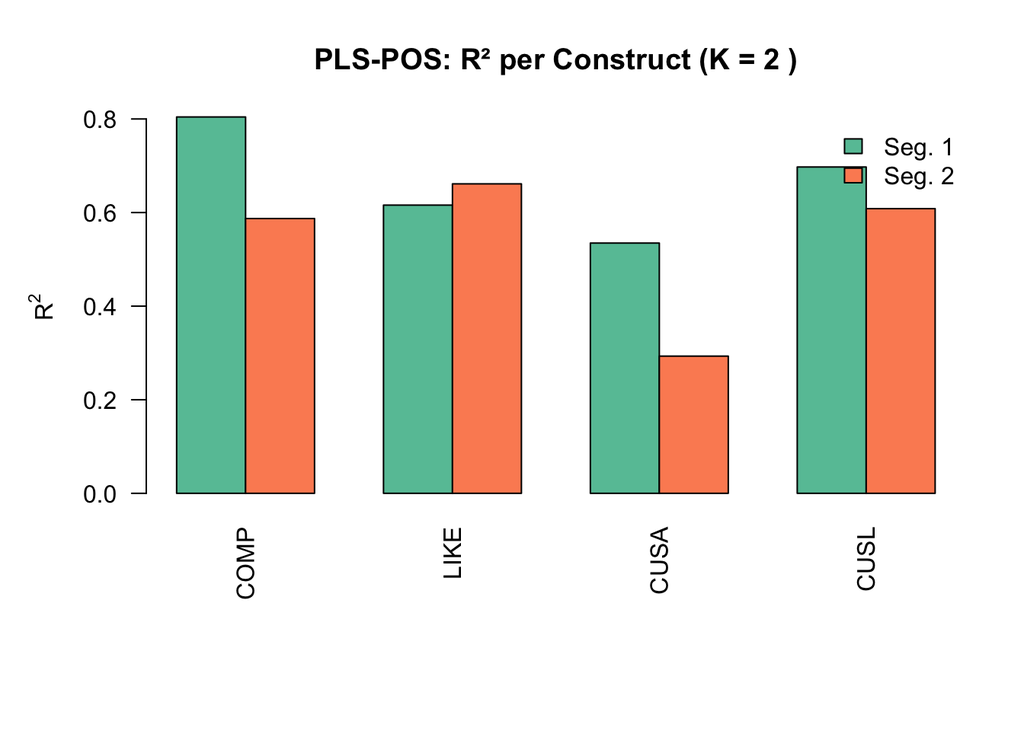

```r
plot(pos_k2, type = "rsquared")
```

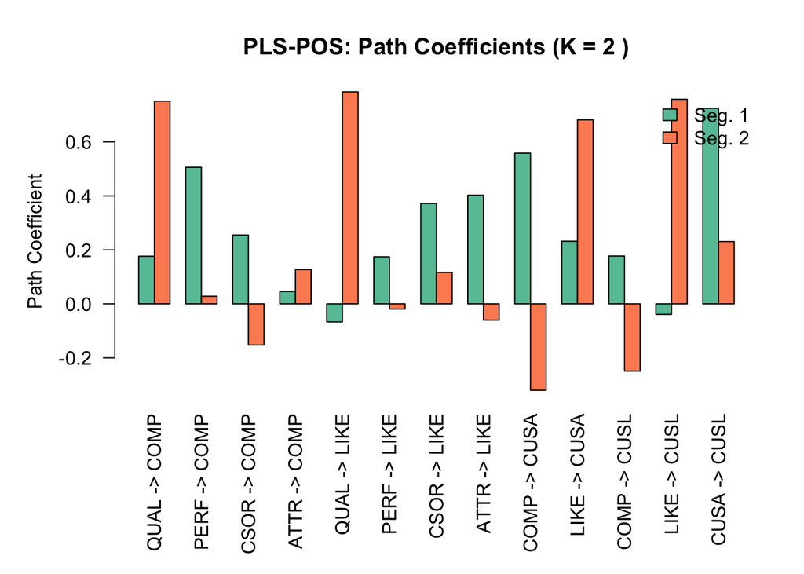

```r
plot(pos_k2, type = "paths")
```

## Extract per-segment models

```r
seg_models <- pos_segments(pos_k2)
summary(seg_models[[1]])
```

```
##
## Results from  package seminr (2.4.2)
##
## Path Coefficients:
##         COMP   LIKE  CUSA   CUSL
## R^2    0.804  0.616 0.535  0.697
## AdjR^2 0.799  0.606 0.529  0.692
## QUAL   0.177 -0.067     .      .
## PERF   0.506  0.175     .      .
## CSOR   0.255  0.372     .      .
## ATTR   0.046  0.403     .      .
## COMP       .      . 0.558  0.177
## LIKE       .      . 0.232 -0.039
## CUSA       .      .     .  0.724
##
## Reliability:
##      alpha  rhoA  rhoC   AVE
## QUAL 0.885 1.000 0.896 0.522
## PERF 0.756 1.000 0.831 0.501
## CSOR 0.810 1.000 0.849 0.536
## ATTR 0.675 1.000 0.813 0.596
## COMP 0.823 0.829 0.894 0.738
## LIKE 0.828 0.844 0.897 0.743
## CUSA 1.000 1.000 1.000 1.000
## CUSL 0.846 0.847 0.907 0.765
##
## Alpha, rhoA, and rhoC should exceed 0.7 while AVE should exceed 0.5
```

## Compare across K

```r
pos_compare <- assess_pos_compare(
  corp_pls,
  K_range  = 2:4,
  nstart   = 10,
  max_iter = 100,
  seed     = 123
)

print(pos_compare)
```

```
## PLS-POS Comparison
## ==================
## K range: 2, 3, 4
##
##  K    Sum_R2 Avg_R2_per_segment Converged Iterations
##  2  4.802607           2.401303      TRUE         68
##  3  7.793681           2.597894      TRUE         85
##  4 10.758069           2.689517     FALSE        100
```

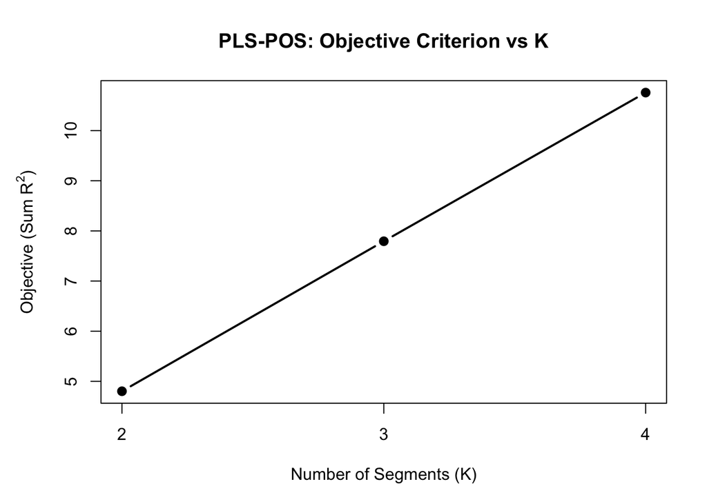

```r
plot(pos_compare)
```

# 8. CTA-PLS (Confirmatory Tetrad Analysis)

Tests whether a construct’s measurement model is consistent with a reflective specification. With `borrow = TRUE` (default), constructs with 2–3 indicators borrow from structurally connected constructs so they can still be tested.

```r
cta_result <- assess_cta(mobi_pls, nboot = 5000, seed = 123)

print(cta_result)
```

```
## Confirmatory Tetrad Analysis (CTA-PLS)
## =======================================
## Bootstrap samples: 5000 | Alpha: 0.05 | Correction: BH
##
## Construct     Mode                                              Indicators  Tetrads  Significant  Verdict
## ----------------------------------------------------------------------------------------------------------------------
## Image         Mode A (reflective)                               5           10       0            Reflective supported
## Expectation   Mode A (reflective) [borrowed from Image]         4           2        0            Reflective supported
## Value         Mode A (reflective) [borrowed from Satisfaction]  4           1        0            Reflective supported
## Satisfaction  Mode A (reflective) [borrowed from Image]         4           2        1            Reflective rejected
## Loyalty       Mode A (reflective) [borrowed from Image]         4           2        0            Reflective supported
##
## Borrowing:
##   Expectation: borrowed from Image (all pattern, 2 vanishing tetrad(s))
##   Value: borrowed from Satisfaction (tau_1342 pattern, 1 vanishing tetrad(s))
##   Satisfaction: borrowed from Image (all pattern, 2 vanishing tetrad(s))
##   Loyalty: borrowed from Image (all pattern, 2 vanishing tetrad(s))
```

```r
summary(cta_result)
```

```
## Confirmatory Tetrad Analysis (CTA-PLS) — Detailed Results
## ==========================================================
## Bootstrap samples: 5000 | Alpha: 0.05 | Correction: BH
##
## --- Image (Mode A (reflective)) ---
## Verdict: Reflective supported
##
##  Tetrad                                                      Estimate T_Value
##  s(IMAG1,IMAG2)s(IMAG3,IMAG4) - s(IMAG1,IMAG3)s(IMAG2,IMAG4) 0.9353   1.5287
##  s(IMAG1,IMAG2)s(IMAG3,IMAG4) - s(IMAG1,IMAG4)s(IMAG2,IMAG3) 1.1614   1.8327
##  s(IMAG1,IMAG2)s(IMAG3,IMAG5) - s(IMAG1,IMAG3)s(IMAG2,IMAG5) 0.5117   0.9215
##  s(IMAG1,IMAG2)s(IMAG3,IMAG5) - s(IMAG1,IMAG5)s(IMAG2,IMAG3) 0.7169   1.4804
##  s(IMAG1,IMAG2)s(IMAG4,IMAG5) - s(IMAG1,IMAG4)s(IMAG2,IMAG5) 0.2872   0.5121
##  s(IMAG1,IMAG2)s(IMAG4,IMAG5) - s(IMAG1,IMAG5)s(IMAG2,IMAG4) 0.3176   0.6330
##  s(IMAG1,IMAG3)s(IMAG4,IMAG5) - s(IMAG1,IMAG4)s(IMAG3,IMAG5) -0.3935  -1.1713
##  s(IMAG1,IMAG3)s(IMAG4,IMAG5) - s(IMAG1,IMAG5)s(IMAG3,IMAG4) -0.6805  -1.7610
##  s(IMAG2,IMAG3)s(IMAG4,IMAG5) - s(IMAG2,IMAG4)s(IMAG3,IMAG5) -0.4601  -1.4450
##  s(IMAG2,IMAG3)s(IMAG4,IMAG5) - s(IMAG2,IMAG5)s(IMAG3,IMAG4) -0.6861  -1.5587
##  Boot_Mean Boot_SD 2.5% CI 97.5% CI P_Value Adj_P  Significant
##  0.9272    0.6118  -0.0974 2.2635   0.0792  0.1896
##  1.1520    0.6337  0.1238  2.5868   0.0280  0.1896
##  0.5037    0.5553  -0.5068 1.7029   0.3428  0.4285
##  0.7059    0.4842  -0.0768 1.7983   0.0884  0.1896
##  0.2872    0.5608  -0.7462 1.4528   0.6084  0.6084
##  0.3144    0.5017  -0.5746 1.4179   0.5352  0.5947
##  -0.3829   0.3359  -1.0682 0.2580   0.2384  0.3406
##  -0.6818   0.3864  -1.4993 0.0107   0.0560  0.1896
##  -0.4524   0.3184  -1.1178 0.1307   0.1356  0.2260
##  -0.6829   0.4402  -1.6298 0.1083   0.0948  0.1896
##
## --- Expectation (Mode A (reflective) [borrowed from Image]) ---
## Borrowed 2 vanishing tetrad(s) from Image (all)
## Verdict: Reflective supported
##
##  Tetrad                                                      Estimate T_Value
##  s(CUEX1,CUEX2)s(CUEX3,IMAG1) - s(CUEX1,CUEX3)s(CUEX2,IMAG1) 0.0937   0.2439
##  s(CUEX1,CUEX2)s(CUEX3,IMAG1) - s(CUEX1,IMAG1)s(CUEX2,CUEX3) 0.4385   1.4817
##  Boot_Mean Boot_SD 2.5% CI 97.5% CI P_Value Adj_P  Significant
##  0.0870    0.3842  -0.6765 0.8310   0.8060  0.8060
##  0.4299    0.2959  -0.0921 1.0674   0.1060  0.2120
```

[output cut: 16 more lines]

```
##  s(CUSA1,CUSA2)s(CUSA3,IMAG1) - s(CUSA1,IMAG1)s(CUSA2,CUSA3) 0.1103   0.3397
##  Boot_Mean Boot_SD 2.5% CI 97.5% CI P_Value Adj_P  Significant
##  0.6273    0.2532  0.1752  1.1605   0.0056  0.0112 *
##  0.1057    0.3248  -0.5275 0.7803   0.7520  0.7520
##
## --- Loyalty (Mode A (reflective) [borrowed from Image]) ---
## Borrowed 2 vanishing tetrad(s) from Image (all)
## Verdict: Reflective supported
##
##  Tetrad                                                      Estimate T_Value
##  s(CUSL1,CUSL2)s(CUSL3,IMAG1) - s(CUSL1,CUSL3)s(CUSL2,IMAG1) 0.2377   0.2280
##  s(CUSL1,CUSL2)s(CUSL3,IMAG1) - s(CUSL1,IMAG1)s(CUSL2,CUSL3) -0.1880  -0.3163
##  Boot_Mean Boot_SD 2.5% CI 97.5% CI P_Value Adj_P  Significant
##  0.2216    1.0425  -1.8345 2.2893   0.8256  0.8256
##  -0.1788   0.5946  -1.3537 0.9875   0.7544  0.8256
```

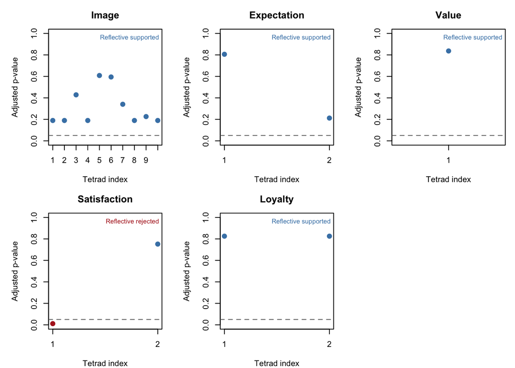

```r
plot(cta_result)
```

### Without borrowing (only constructs with ≥ 4 indicators)

```r
cta_no_borrow <- assess_cta(mobi_pls, nboot = 5000, borrow = FALSE, seed = 123)
print(cta_no_borrow)
```

```
## Confirmatory Tetrad Analysis (CTA-PLS)
## =======================================
## Bootstrap samples: 5000 | Alpha: 0.05 | Correction: BH
##
## Construct  Mode                 Indicators  Tetrads  Significant  Verdict
## --------------------------------------------------------------------------------------
## Image      Mode A (reflective)  5           10       0            Reflective supported
##
## Skipped: Expectation, Value, Satisfaction, Loyalty
```

# 9. PCM (Predictive Contribution of the Mediator)

Does the mediator actually improve out-of-sample prediction? Compares Direct-Antecedent (DA) and Earliest-Antecedent (EA) predictions on the isolated mediation sub-model (Danks, 2021). Mediation paths are auto-detected.

## Single-mediator model

```r
# Use a minimal mediation model: Image -> Satisfaction -> Loyalty (+ direct)
pcm_mm <- constructs(
  composite("Image",        multi_items("IMAG", 1:5)),
  composite("Satisfaction", multi_items("CUSA", 1:3)),
  composite("Loyalty",      multi_items("CUSL", 1:3))
)
pcm_sm <- relationships(
  paths(from = "Image",        to = "Satisfaction"),
  paths(from = "Satisfaction", to = "Loyalty"),
  paths(from = "Image",        to = "Loyalty")
)
pcm_pls <- estimate_pls(mobi, pcm_mm, pcm_sm)

pcm_result <- assess_pcm(
  pcm_pls,
  target  = "Loyalty",
  noFolds = 10,
  reps    = 10
)

pcm_result
```

```
## Predictive Contribution of the Mediator (PCM)
## ==============================================
## Target: Loyalty
## Cross-validation: 10 folds, 10 reps
## Mediation paths: 1
##
##   Image -> Satisfaction -> Loyalty
##     Avg PCM (RMSE):  0.0473  [Weak]
##     Avg PCM (MAE):   0.0618  [Moderate]
```

```r
summary(pcm_result)
```

```
## Predictive Contribution of the Mediator (PCM)
## ==============================================
## Target: Loyalty
## Cross-validation: 10 folds, 10 reps
##
## Mediation: Image -> Satisfaction -> Loyalty
## ------------------------------------------------------------
##   Indicator     RMSE_DA  RMSE_EA  PCM_RMSE   MAE_DA   MAE_EA   PCM_MAE  Conclusion
##   CUSL1          2.3675   2.4142    0.0194   1.7538   1.8101    0.0311  Weak
##   CUSL2          2.8289   2.8523    0.0082   2.3983   2.4078    0.0039  Weak
##   CUSL3          1.6664   1.8812    0.1142   1.1793   1.3878    0.1503  Strong
##
## PCM thresholds: < 0 Negative | 0-0.05 Weak | 0.05-0.10 Moderate | > 0.10 Strong
## Reference: Danks (2021), The DATA BASE for Advances in IS, 52(SI), 24-42.
```

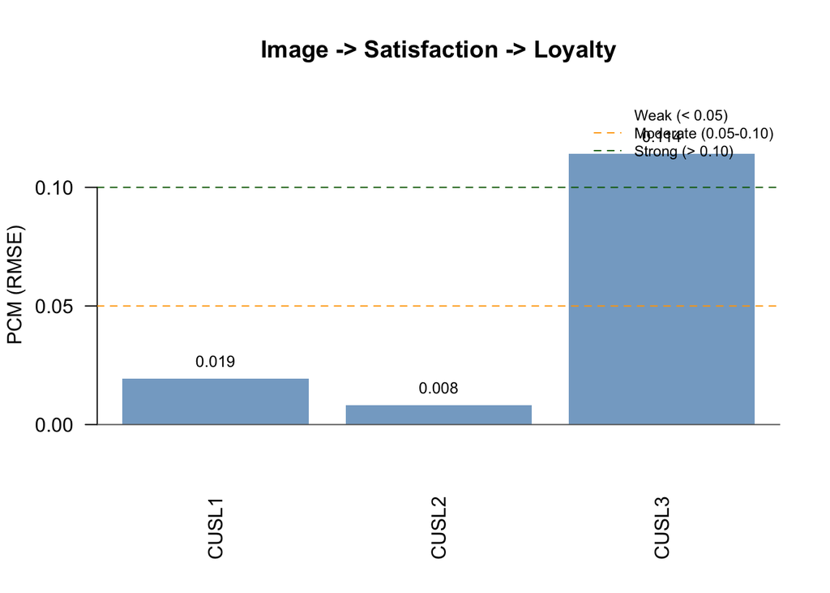

```r
plot(pcm_result)
```

## Multi-mediator model (auto-detects all paths)

```r
pcm_full <- assess_pcm(
  mobi_pls,
  target  = "Loyalty",
  noFolds = 10,
  reps    = 10
)

pcm_full
```

```
## Predictive Contribution of the Mediator (PCM)
## ==============================================
## Target: Loyalty
## Cross-validation: 10 folds, 10 reps
## Mediation paths: 3
##
##   Image -> Satisfaction -> Loyalty
##     Avg PCM (RMSE):  0.0457  [Weak]
##     Avg PCM (MAE):   0.0601  [Moderate]
##
##   Expectation -> Satisfaction -> Loyalty
##     Avg PCM (RMSE):  0.0852  [Moderate]
##     Avg PCM (MAE):   0.1113  [Strong]
##
##   Value -> Satisfaction -> Loyalty
##     Avg PCM (RMSE):  0.0516  [Moderate]
##     Avg PCM (MAE):   0.0744  [Moderate]
```

```r
summary(pcm_full)
```

```
## Predictive Contribution of the Mediator (PCM)
## ==============================================
## Target: Loyalty
## Cross-validation: 10 folds, 10 reps
##
## Mediation: Image -> Satisfaction -> Loyalty
## ------------------------------------------------------------
##   Indicator     RMSE_DA  RMSE_EA  PCM_RMSE   MAE_DA   MAE_EA   PCM_MAE  Conclusion
##   CUSL1          2.3644   2.4148    0.0209   1.7485   1.8084    0.0331  Weak
##   CUSL2          2.8288   2.8367    0.0028   2.3972   2.3922   -0.0021  Weak
##   CUSL3          1.6715   1.8854    0.1134   1.1792   1.3860    0.1492  Strong
##
## Mediation: Expectation -> Satisfaction -> Loyalty
## ------------------------------------------------------------
##   Indicator     RMSE_DA  RMSE_EA  PCM_RMSE   MAE_DA   MAE_EA   PCM_MAE  Conclusion
##   CUSL1          2.3848   2.5764    0.0744   1.7836   2.0174    0.1159  Moderate
##   CUSL2          2.8627   2.8371   -0.0090   2.4217   2.3934   -0.0118  Negative
##   CUSL3          1.6961   2.0948    0.1904   1.2065   1.5663    0.2297  Strong
##
## Mediation: Value -> Satisfaction -> Loyalty
## ------------------------------------------------------------
##   Indicator     RMSE_DA  RMSE_EA  PCM_RMSE   MAE_DA   MAE_EA   PCM_MAE  Conclusion
##   CUSL1          2.3649   2.4422    0.0316   1.7500   1.8357    0.0467  Weak
##   CUSL2          2.8470   2.8298   -0.0061   2.4116   2.3942   -0.0073  Negative
##   CUSL3          1.6854   1.9353    0.1292   1.1853   1.4524    0.1839  Strong
##
## PCM thresholds: < 0 Negative | 0-0.05 Weak | 0.05-0.10 Moderate | > 0.10 Strong
## Reference: Danks (2021), The DATA BASE for Advances in IS, 52(SI), 24-42.
```

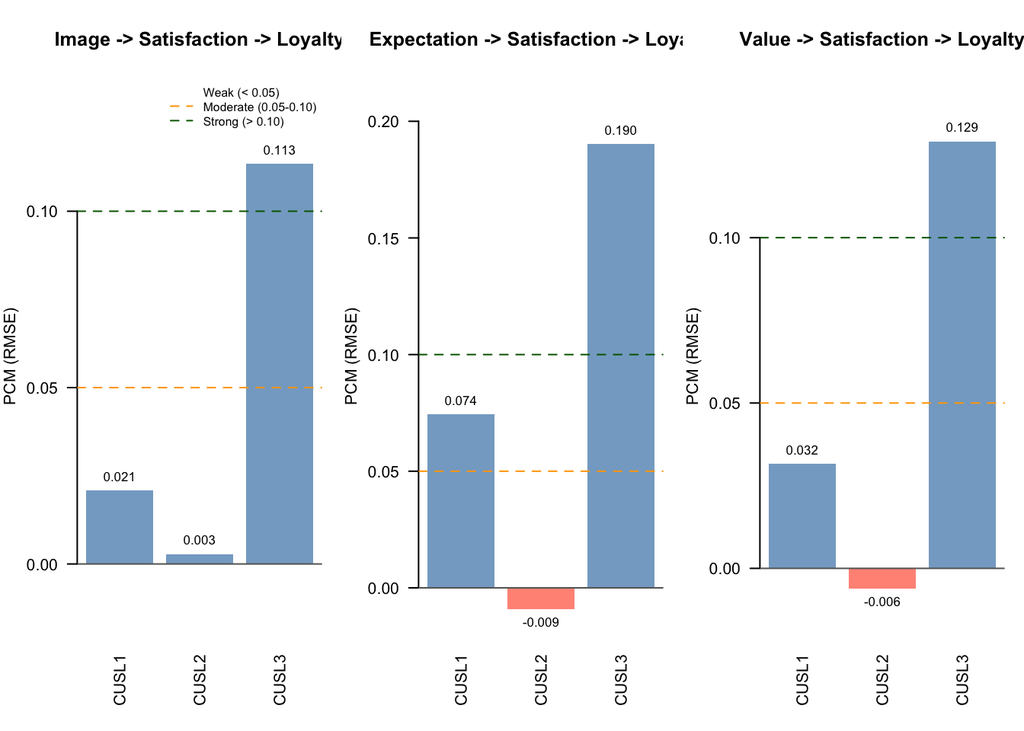

```r
plot(pcm_full)
```

# 10. Hardened CVPAT and congruence testing

## CVPAT (single model + model comparison)

```r
# Alternative structural model: drop CUSL from COMP/LIKE block
alt_sm <- relationships(
  paths(from = c("QUAL", "PERF", "CSOR", "ATTR"), to = c("COMP", "LIKE")),
  paths(from = c("COMP", "LIKE"),                 to = "CUSA"),
  paths(from = "CUSA",                            to = "CUSL")
)

corp_pls_alt <- estimate_pls(
  data              = corp_rep_data,
  measurement_model = corp_rep_mm,
  structural_model  = alt_sm,
  missing           = mean_replacement,
  missing_value     = "-99"
)

# Assess the focal model
cvpat_focal <- assess_cvpat(
  corp_pls,
  testtype  = "two.sided",
  nboot     = 2000,
  seed      = 123,
  technique = predict_DA,
  noFolds   = 10,
  reps      = 10
)
print(cvpat_focal$CVPAT_compare_LM, digits = 3)
```

```
##         PLS Loss LM Loss   Diff Boot T value Boot P Value
## COMP       1.198   1.232 -0.034        1.156        0.249
## LIKE       1.923   2.084 -0.162        4.014        0.000
## CUSA       0.988   0.973  0.015       -0.612        0.541
## CUSL       1.562   1.621 -0.058        3.510        0.001
## Overall    1.418   1.477 -0.060        4.177        0.000
##
## CVPAT as per Sharma et al. (2023).
```

```r
print(cvpat_focal$CVPAT_compare_IA, digits = 3)
```

```
##         PLS Loss IA Loss   Diff Boot T value Boot P Value
## COMP       1.198   2.023 -0.825        8.578        0.000
## LIKE       1.923   3.103 -1.180        8.249        0.000
## CUSA       0.988   1.374 -0.386        5.070        0.000
## CUSL       1.562   2.663 -1.100        7.542        0.000
## Overall    1.418   2.290 -0.873       10.269        0.000
##
## CVPAT as per Sharma et al. (2023).
```

```r
# Compare focal vs. alternative
cvpat_cmp <- assess_cvpat_compare(
  established_model = corp_pls,
  alternative_model = corp_pls_alt,
  testtype  = "two.sided",
  nboot     = 2000,
  technique = predict_DA,
  seed      = 123,
  noFolds   = 10,
  reps      = 10,
  cores     = NULL
)
print(cvpat_cmp, digits = 3)
```

```
##         Base Model Loss Alt Model Loss   Diff Boot T value Boot P Value
## COMP              1.198          1.195  0.003       -0.460        0.645
## LIKE              1.923          1.933 -0.010        0.883        0.378
## CUSA              0.988          0.992 -0.004        0.809        0.419
## CUSL              1.562          1.715 -0.152        3.286        0.001
## Overall           1.418          1.459 -0.041        3.293        0.001
##
## CVPAT as per Sharma, Liengaard, Hair, Sarstedt, & Ringle, (2023).
##   Both models under comparison have identical endogenous constructs with identical measurement models.
##   Purely exogenous constructs can differ in regards to their relationships with both nomological
##   partners and measurement indicators.
```

## Congruence test

Tests whether the congruence coefficients between original PLS composite weights and bootstrapped weights are significantly close to 1.

```r
cong_result <- congruence_test(
  mobi_pls,
  nboot     = 2000,
  seed      = 123,
  alpha     = 0.05,
  threshold = 1
)

print(cong_result)
```

```
## $results
##                               Original Est.  Diff Bootstrap SD T Stat. 2.5% CI
## Image  ->  Expectation                0.947 0.053        0.024   2.222   0.888
## Image  ->  Value                      0.924 0.076        0.028   2.700   0.852
## Image  ->  Satisfaction               0.974 0.026        0.016   1.680   0.932
## Image  ->  Loyalty                    0.910 0.090        0.037   2.453   0.822
## Expectation  ->  Value                0.987 0.013        0.005   2.290   0.973
## Expectation  ->  Satisfaction         0.862 0.138        0.053   2.601   0.731
## Expectation  ->  Loyalty              0.947 0.053        0.025   2.122   0.883
## Value  ->  Satisfaction               0.937 0.063        0.027   2.355   0.875
## Value  ->  Loyalty                    0.947 0.053        0.023   2.336   0.888
## Satisfaction  ->  Loyalty             0.989 0.011        0.013   0.846   0.950
##                               97.5% CI
## Image  ->  Expectation           0.980
## Image  ->  Value                 0.962
## Image  ->  Satisfaction          0.992
## Image  ->  Loyalty               0.962
## Expectation  ->  Value           0.995
## Expectation  ->  Satisfaction    0.939
## Expectation  ->  Loyalty         0.978
## Value  ->  Satisfaction          0.976
## Value  ->  Loyalty               0.977
## Satisfaction  ->  Loyalty        0.999
```

```r
summary(cong_result)
```

```
##         Length Class        Mode
## results 60     table_output numeric
```